# apresentacao_projeto1

[figure not shown]

UEPB UNIVERSIDADE ESTADUAL  
DA PARAÍBA

PROJETO 01  
SÉRIES TEMPORAIS

Modelos de Suavização Exponencial (ETS)

ELIZEU SILVA DE MEDEIROS

GRADUAÇÃO EM ESTATÍSTICA

24/06/2026

## SÉRIES EM ESTUDO

### Energia

- Série referente a curva de carga horária de energia do Subsistema SUDESTE/CO do Operador Nacional do Sistema Elétrico (ONS).
- Os dados da série são sobre média da energia (em horas).
- Para esse estudo, os valores da série foram agrupados por DIA.
- O agrupamento diário dos valores da série de energia foi feito através da media das horas, ou seja. “A média, da média.”
- Pensando intuitivamente, a série vai ter: Sazonalidade, Tendencia e nesse caso em especifico vai sofrer com OSCILAÇÕES NO CALENDÁRIO (feriados, fim de semana, etc…).

### Crédito total

- Série mensal referente ao CRÉDITO TOTAL, divulgadas pelo Banco Central do Brasil.
- CRÉDITO TOTAL: seria as operações de crédito (empréstimos ao mercado) do sistema financeiro nacional.
- Os dados da série são mensais.
- Pensando intuitivamente a série vai ter: TENDENCIA CRESCENTE, SEM sazonalidade explicita.

Objetivo: avaliar como os modelos de suavização se comportam nos dois contextos.

## FUNDAMENTAÇÃO TEÓRICA (1/4)

- Holt
- Holt Amortecido
- Holt-Winters
- STLF

O modelo de *Holt* trata-se de uma extensão do modelo de *Suavização Exponencial Simples*, pois ele incorpora dois componentes: nível (valor médio atual da série) e tendência.

$$\hat{y}_{t+h} = \ell_t + h b_t$$
$$\ell_t = \alpha y_t + (1-\alpha)(\ell_{t-1} + b_{t-1})$$
$$b_t = \beta^*(\ell_t - \ell_{t-1}) + (1-\beta^*)b_{t-1}$$

Conforme proposto por Holt (1957) e sistematizado em Hyndman e Athanasopoulos (2018).

O modelo de *Holt Amortecido (*Holt Damped*)* introduz um parâmetro de amortecimento $\phi \in (0,1)$ que reduz progressivamente a influência da tendência no ambiente de previsão. Buscando evitar que o modelo extrapole indefinidamente uma tendência linear, tornando as previsões mais conservadoras em horizontes de previsão longos.

$$\hat{y}_{t+h} = \ell_t + (\phi + \phi^2 + \cdots + \phi^h) b_t$$
$$\ell_t = \alpha y_t + (1-\alpha)(\ell_{t-1} + \phi b_{t-1})$$
$$b_t = \beta^*(\ell_t - \ell_{t-1}) + (1-\beta^*)\phi b_{t-1}$$

Conforme proposto por Gardner e McKenzie (1985) e discutido em Hyndman e Athanasopoulos (2018).

O modelo de *Holt-Winters* acrescenta ao modelo de Holt um terceiro componente de sazonalidade, existindo duas versões: ADITIVA e MULTIPLICATIVA.

**Versão aditiva:**
$$\hat{y}_{t+h} = \ell_t + h b_t + s_{t+h-m(k+1)}$$

**Versão multiplicativa:**
$$\hat{y}_{t+h} = (\ell_t + h b_t)\, s_{t+h-m(k+1)}$$

Conforme proposto por Winters (1960) e sistematizado em Hyndman e Athanasopoulos (2018).

O STLF (*Seasonal and Trend decomposition using Loess Forecasting*) realiza uma decomposição sazonal da série via STL e aplica um modelo de previsão. A sazonalidade dessa previsão é extraída é então readicionada à previsão final. Permitindo tratar sazonalidades complexas de forma flexível, sendo particularmente adequado para séries com múltiplos períodos sazonais.

$$y_t = T_t + S_t + R_t$$

em que $T_t$ é a tendência, $S_t$ a sazonalidade e $R_t$ o resíduo estimados via Loess. A previsão é obtida modelando $T_t + R_t$ e somando $S_t$ projetada.

Conforme proposto por Cleveland et al. (1990).

## FUNDAMENTAÇÃO TEÓRICA (2/4)

- Sazonalidade Complexa
- Previsão de UM Passo à frente

Foi adotado *Sazonalidade complexa* considerando padrão semanal (período 7) e um padrão anual (período 365), o que inviabiliza o uso direto de modelos clássicos como Holt-Winters, que suportam apenas UM PERÍODO SAZONAL.

Por isso, o STLF foi empregado na série de energia, sendo capaz de decompor e lidar com essa estrutura via STL.

Na série de crédito, a frequência é mensal com período 12, de modo que a sazonalidade é simples e os modelos clássicos puderam ser aplicados diretamente.

Conforme discutido em Hyndman e Athanasopoulos (2018).

Conforme discutido em Hyndman e Athanasopoulos (2018).

## FUNDAMENTAÇÃO TEÓRICA (3/4)

- RMSE
- MAE
- MAPE
- sMAPE
- MASE
- THEIL U
- UMBRAE

O RMSE (*Root Mean Squared Error: Raiz do Erro Quadrático Médio*) mede a magnitude média dos erros de previsão, penalizando mais fortemente erros grandes devido à elevação dos desvios ao quadrado.

$$\text{RMSE}
=
\sqrt{\frac{1}{n}\sum_{t=1}^{n}(y_t-\hat{y}_t)^2}$$

No geral, quanto menor o RMSE, MELHOR.

O MAE (*Mean Absolute Error: Erro Absoluto Médio*) representa a média dos erros absolutos entre os valores observados e previstos, atribuindo o mesmo peso a todos os desvios.

$$\text{MAE}
=
\frac{1}{n}\sum_{t=1}^{n}|y_t-\hat{y}_t|$$

No geral, quanto menor o MAE, MELHOR.

O MAPE (*Mean Absolute Percentage Error: Erro Percentual Absoluto Médio*) expressa o erro médio das previsões como percentual dos valores observados.

$$\text{MAPE}
=
\frac{100}{n}\sum_{t=1}^{n}\left|\frac{y_t-\hat{y}_t}{y_t}\right|$$

No geral, quanto menor o percentual do MAPE, MELHOR.

O sMAPE (*Symmetric Mean Absolute Percentage Error: Erro Percentual Absoluto Médio Simétrico*) reduz parcialmente a assimetria do MAPE utilizando a soma dos valores observado e previsto no denominador.

$$\text{sMAPE}
=
\frac{200}{n}\sum_{t=1}^{n}
\frac{|y_t-\hat{y}_t|}
{|y_t|+|\hat{y}_t|}$$

No geral, quanto menor o percentual do sMAPE, MELHOR.

O MASE (*Mean Absolute Scaled Error: Erro Absoluto Médio Escalado*) compara o erro médio absoluto do modelo com o erro obtido por uma previsão ingênua, permitindo comparações entre séries de diferentes escalas.

$$\text{MASE}
=
\frac{\text{MAE}}
{\frac{1}{T-m}\sum_{t=m+1}^{T}|y_t-y_{t-m}|}$$

- **MASE = 0:** previsão perfeita.
- **MASE < 1:** o modelo é melhor que a previsão ingênua.
- **MASE = 1:** o modelo possui desempenho equivalente à previsão ingênua.
- **MASE > 1:** o modelo é pior que a previsão ingênua.

O índice (ou estatística) de Theil U (*Theil’s U Statistic*), compara o desempenho do modelo de previsão com o de uma previsão ingênua (*naive forecast*).

$$U=
\frac{
\sqrt{\frac{1}{n}\sum_{t=1}^{n}(y_t-\hat{y}_t)^2}
}{
\sqrt{\frac{1}{n}\sum_{t=1}^{n}(y_t-y_{t-1})^2}
}$$

em que:

- $(U < 1)$: **o modelo de previsão apresenta desempenho superior ao da previsão ingênua.**
- $(U = 1)$: o modelo possui desempenho **equivalente** ao da previsão ingênua.
- $(U > 1)$: o modelo apresenta desempenho inferior ao da previsão ingênua.

O UMBRAE (*Unscaled Mean Bounded Relative Absolute Error: Erro Absoluto Relativo Médio Limitado Não Escalonado*), corrige a instabilidade do MASE por meio de um erro relativo limitado ao intervalo entre 0 e 1.

$$\mathrm{UMBRAE}
=
\frac{1}{n}
\sum_{t=1}^{n}
\frac{|y_t-\hat{y}_t|}
{|y_t-\hat{y}_t|+|y_t-y_t^{(b)}|}$$

em que:

- $y_t$ é o valor observado;
- $\hat{y}_t$ é o valor previsto pelo modelo avaliado;
- $y_t^{(b)}$ é a previsão do modelo de referência (*benchmark*), geralmente a previsão ingênua;
- $n$ é o número de observações.

No geral, quanto menor o UMBRAE, MELHOR.

## FUNDAMENTAÇÃO TEÓRICA (4/4)

- Teste de Ljung-Box

Foi utlizado o *Teste de Ljung-Box* para avaliar se os resíduos dos modelos apresentam autocorrelação, testando conjuntamente as primeiras $h$ defasagens da função de autocorrelação.

**Hipóteses a serem testadas:**

- $H_0$: os resíduos são independentes (sem autocorrelação até a defasagem $h$): RUIDO BRANCO
- $H_1$: existe autocorrelação em pelo menos uma defasagem

Conforme Ljung e Box (1978) e discutido em Hyndman e Athanasopoulos (2018).

## METODOLOGIA

Divisão Temporal: energia 80,8% treino e 19,2% teste; crédito 86,1% treino e 13,9% teste.

## ENERGIA: SÉRIE COMPLETA

- Gráfico
- Leitura

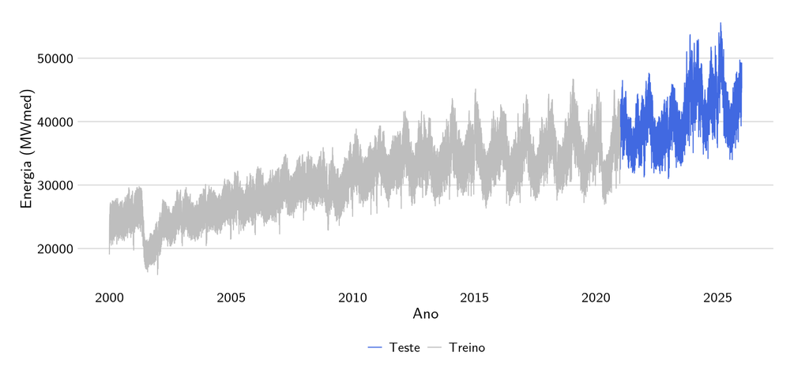

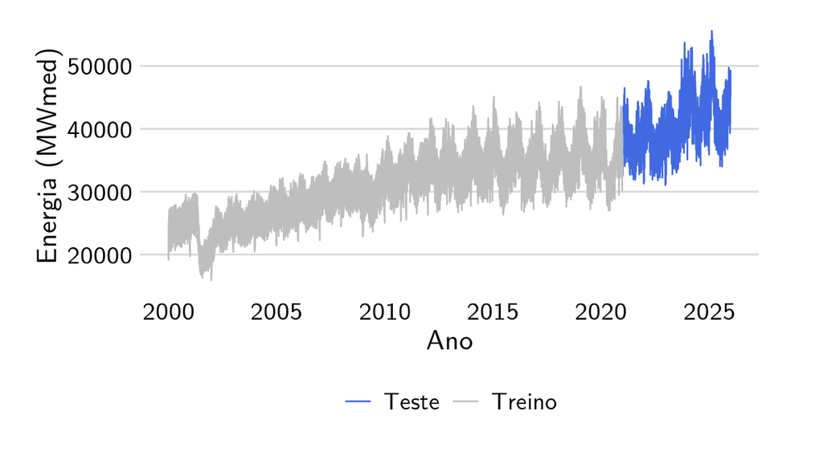

## ENERGIA: EDA (1/2)

- Gráfico
- Leitura

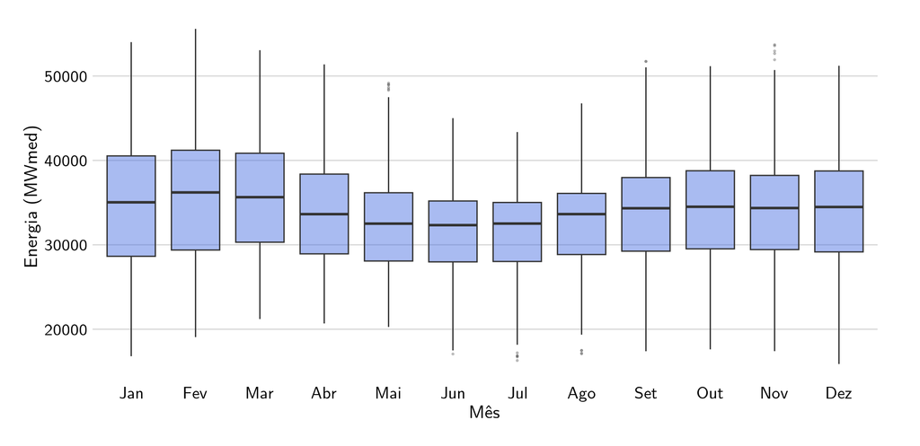

- Boxplot da Média mensal de energia, considerando todos os anos.
- Em alguns meses as medianas são maiores.
- Amplitude Interquartilica semelhante.
- Em alguns meses ocorre OutLiers.

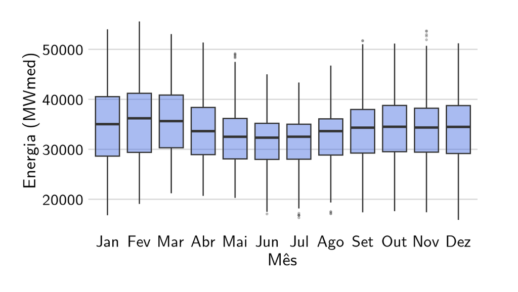

## ENERGIA: EDA (2/2)

- Gráfico
- Leitura

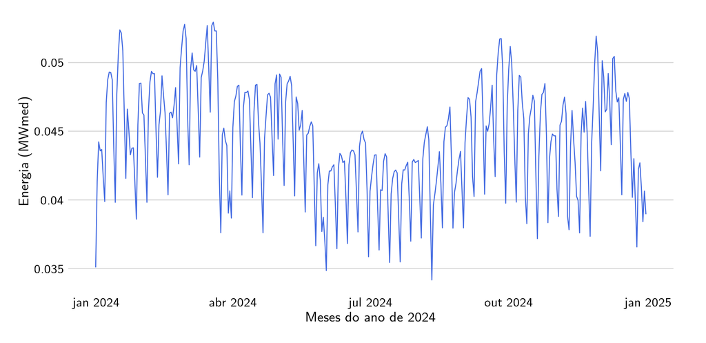

- Gráfico de Linhas do recorte do ano de 2024.
- Observa-se a presença de sazonalidade.
- Tem dias que apresentam valores maiores de consumo.

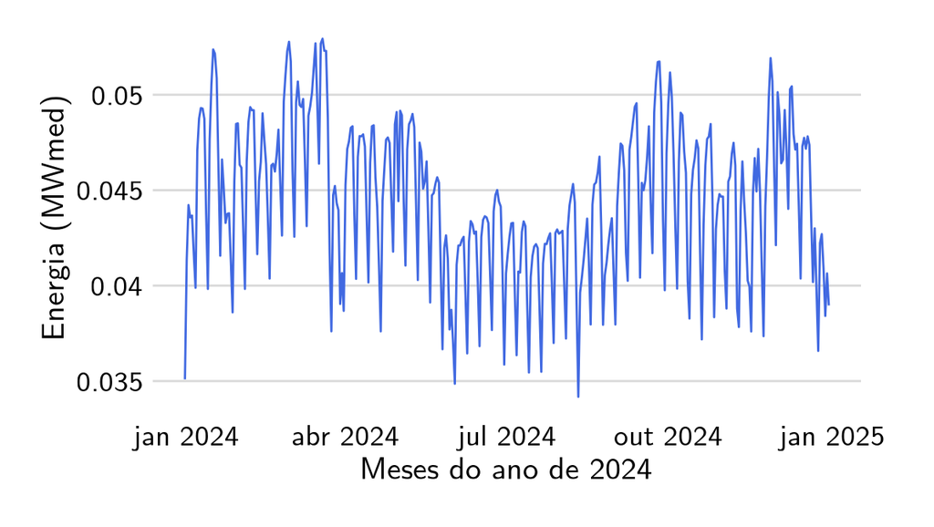

## ENERGIA: REAL vs PREVISTO

- STLF
- Holt
- Holt-Damped
- HW-Aditivo
- HW-Multiplicativo

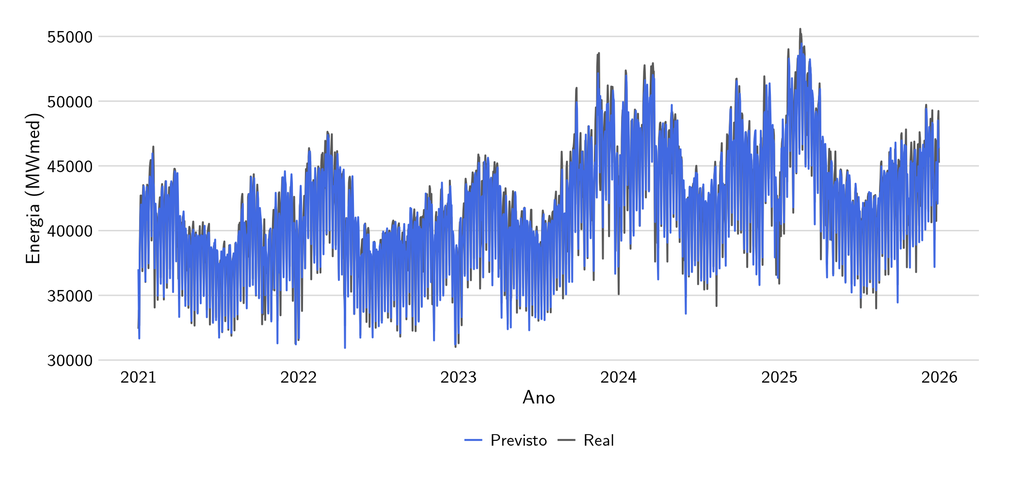

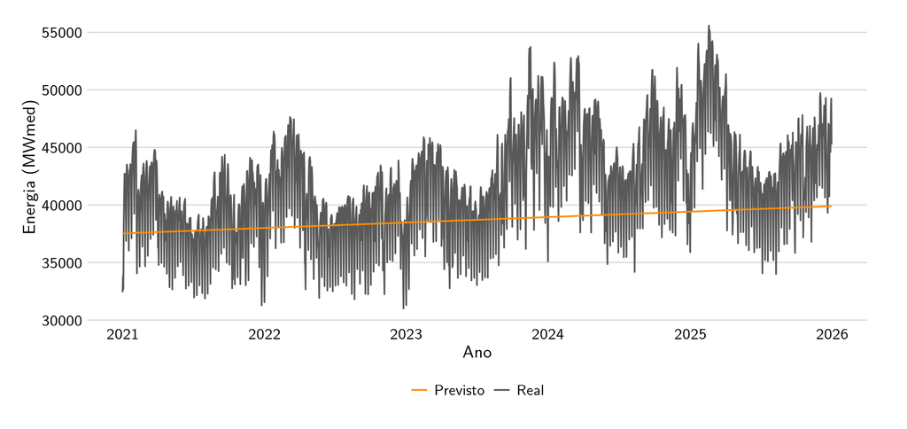

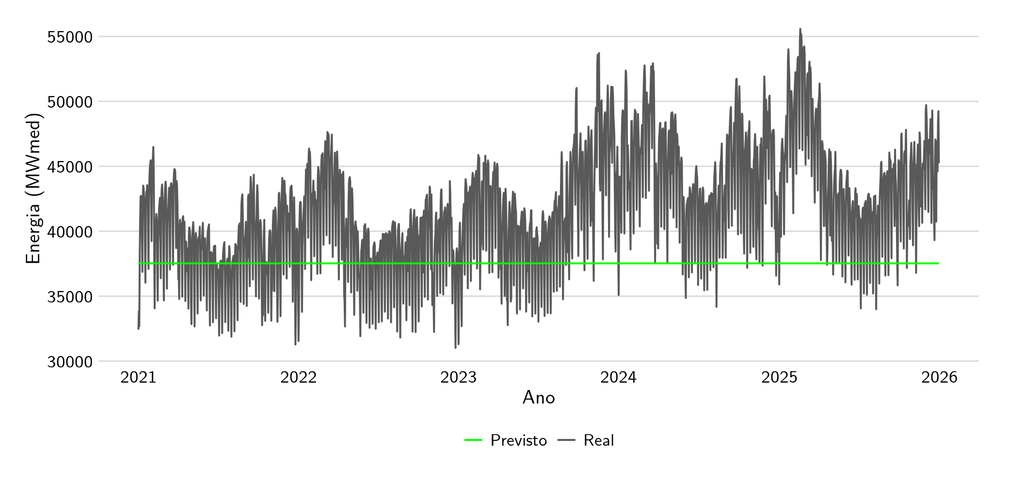

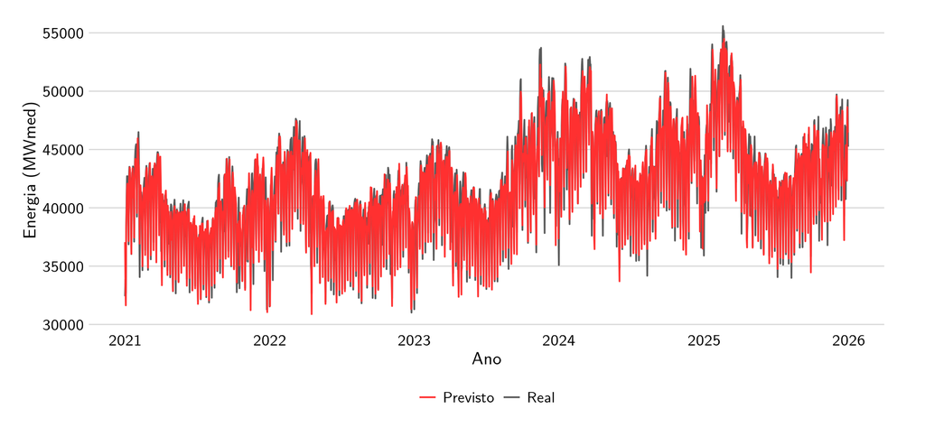

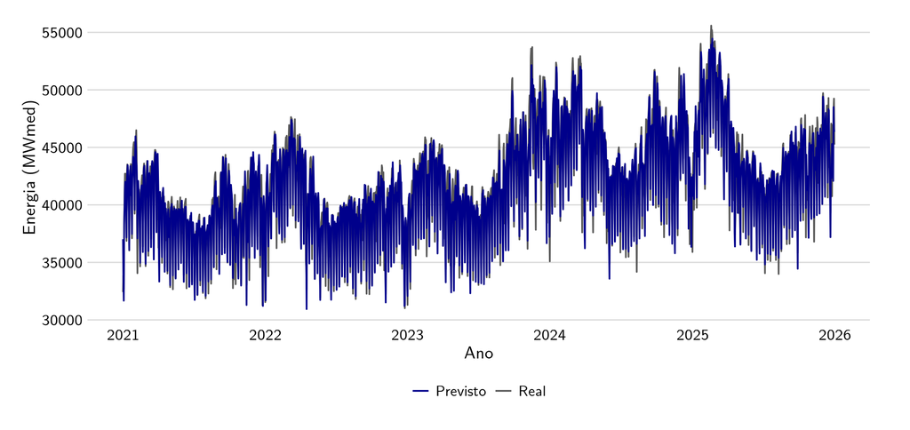

## ENERGIA: COMPARAÇÃO DAS MÉTRICAS

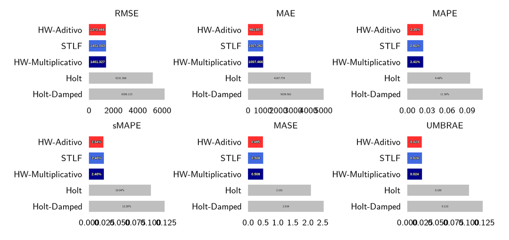

## ENERGIA: ANÁLISE RESIDUAL

- Histograma(s)
- Teste de Ljung-Box

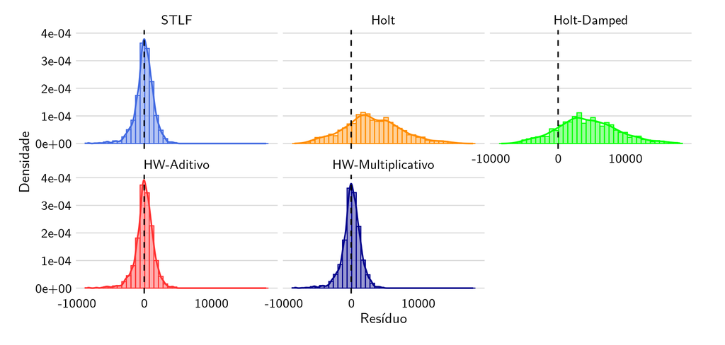

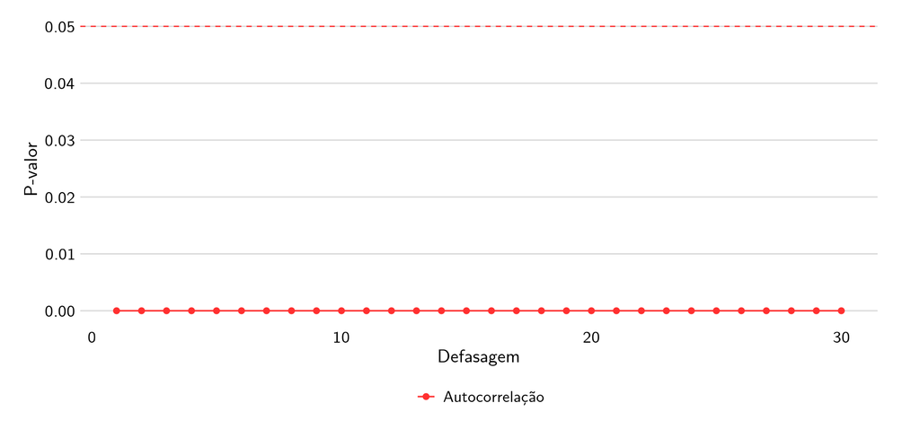

## CRÉDITO: SÉRIE COMPLETA

- Gráfico
- Leitura

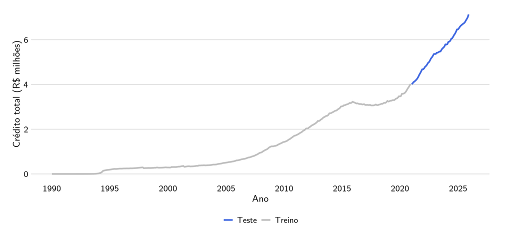

- Série mensal
- Crescimento persistente
- Escala recente muito maior
- Modelagem usa o trecho positivo

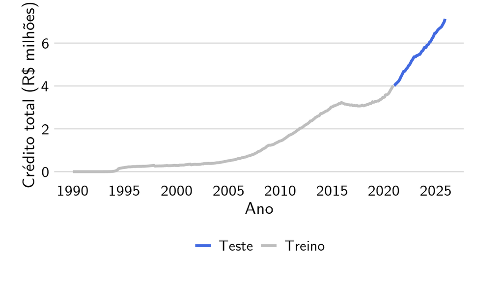

## CRÉDITO: EDA (1/2)

- Gráfico
- Leitura

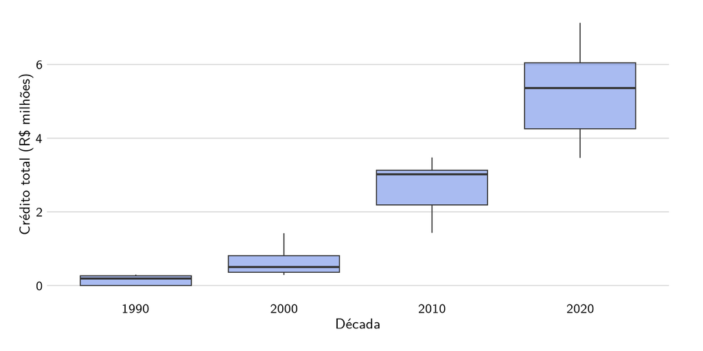

- Boxplot por década do Crédito Total (R$ milhões).
- É possível evidenciar o crescimento exponencial do crédito.
- Não há OutLiers nas decadas selecionadas.

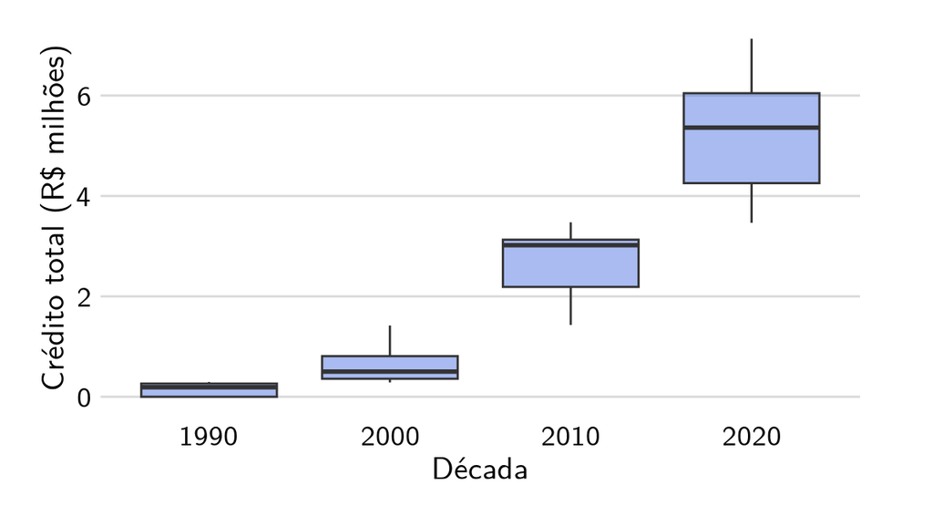

## CRÉDITO: EDA (2/2)

- Gráfico
- Leitura

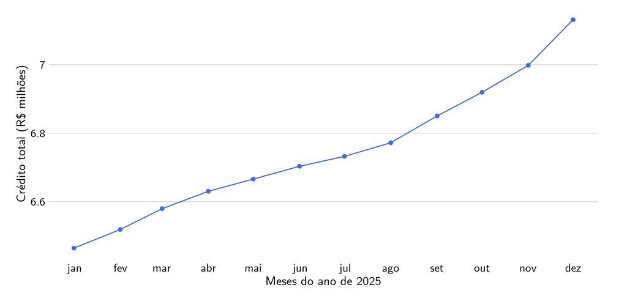

- Gráfico de Linhas do recorte do ano de 2025.
- Não há padrão sazonal no recorte.
- TENDÊNCIA CRESCENTE evidente na série.

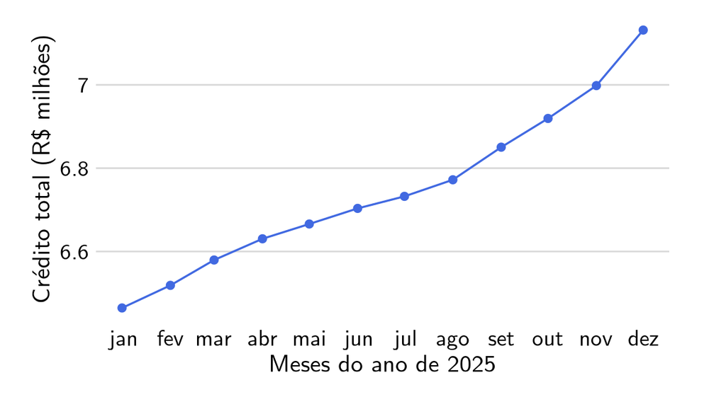

## CRÉDITO: REAL vs PREVISTO

- STLF
- Holt
- Holt-Damped
- HW-Aditivo
- HW-Multiplicativo

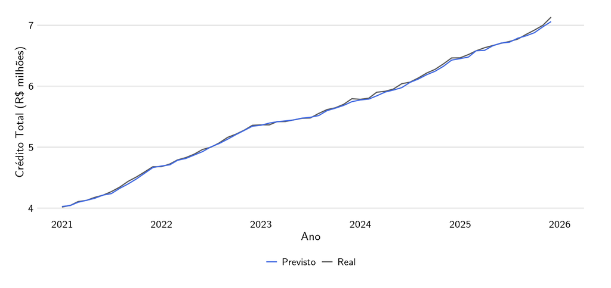

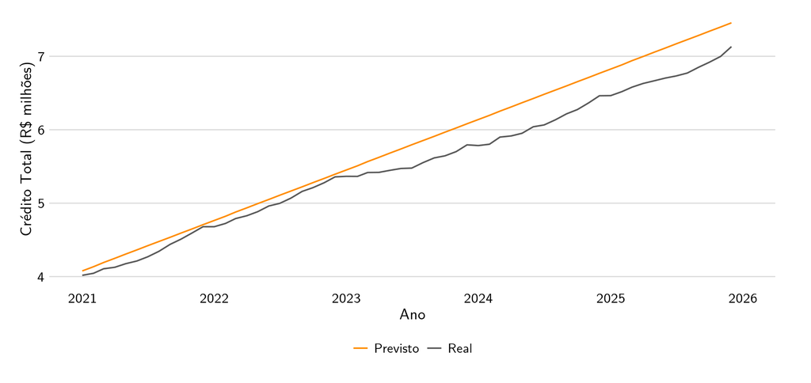

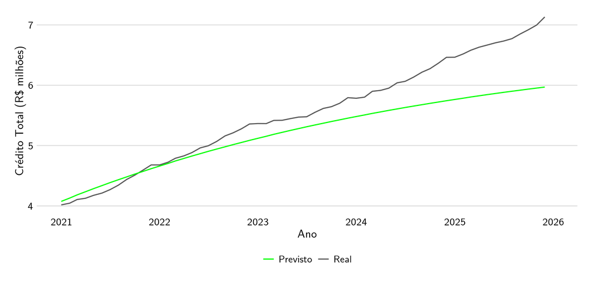

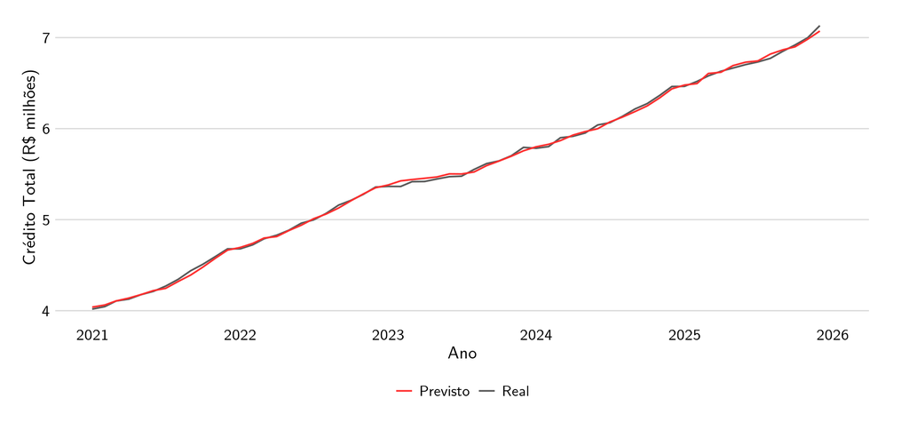

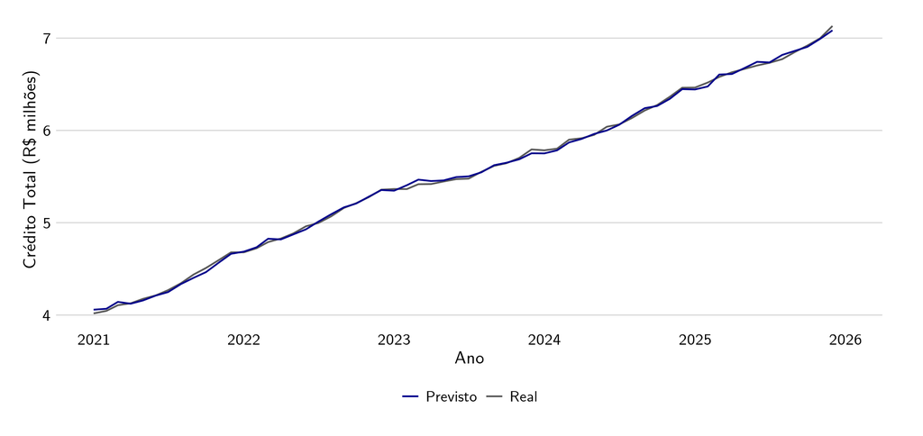

## CRÉDITO: COMPARAÇÃO DAS MÉTRICAS

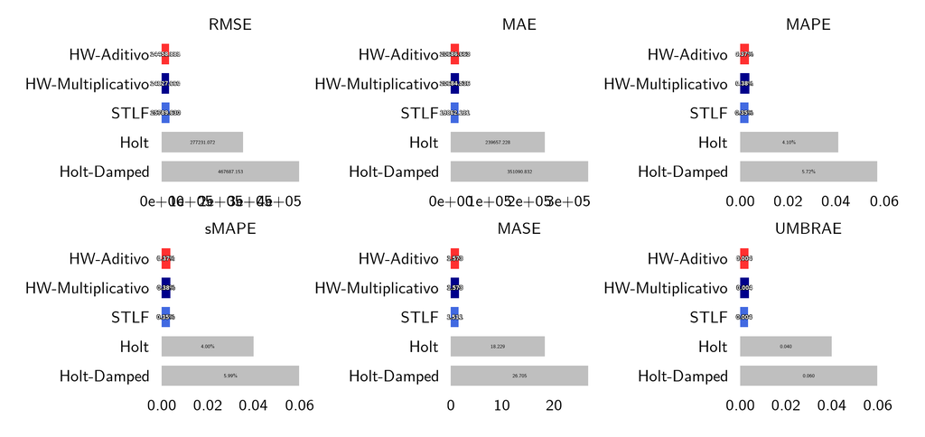

## CRÉDITO: ANÁLISE RESIDUAL

- Histograma(s)
- Teste de Ljung-Box

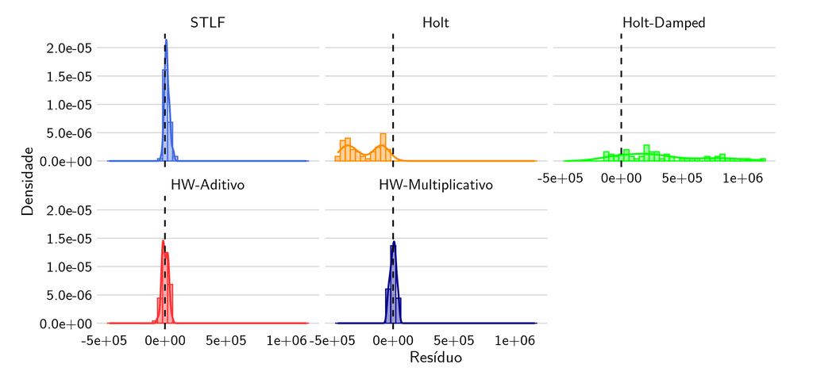

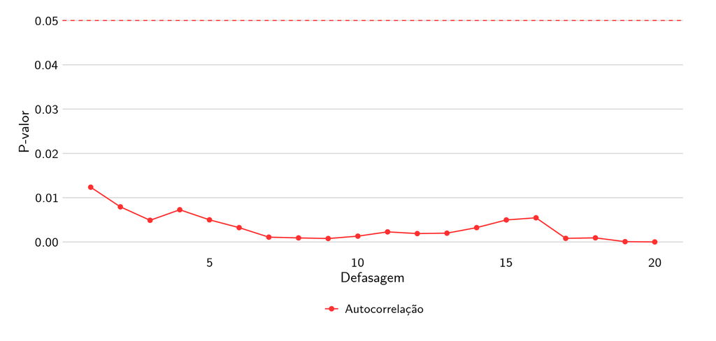

## REFERÊNCIAS

- **LJUNG, G. M.; BOX, G. E. P.** On a measure of lack of fit in time series models. *Biometrika*, v. 65, n. 2, p. 297–303, 1978.
- **CLEVELAND, R. B.** et al. STL: a seasonal-trend decomposition procedure based on Loess. *Journal of Official Statistics*, v. 6, n. 1, p. 3–33, 1990.
- **DIEBOLD, F. X.; MARIANO, R. S.** Comparing predictive accuracy. *Journal of Business & Economic Statistics*, v. 13, n. 3, p. 253–263, 1995.
- **GARDNER, E. S.; McKENZIE, E.** Forecasting trends in time series. *Management Science*, v. 31, n. 10, p. 1237–1246, 1985.
- **HOLT, C. C.** Forecasting seasonals and trends by exponentially weighted moving averages. *ONR Memorandum*, n. 52, Carnegie Institute of Technology, 1957.
- **HYNDMAN, R. J.; ATHANASOPOULOS, G.** *Forecasting: Principles and Practice*. 3. ed. Melbourne: OTexts, 2018. Disponível em: https://otexts.com/fpp3. Acesso em: 2025.
- **HYNDMAN, R. J.; KOEHLER, A. B.** Another look at measures of forecast accuracy. *International Journal of Forecasting*, v. 22, n. 4, p. 679–688, 2006.
- **THEIL, H.** *Applied Economic Forecasting*. Amsterdam: North-Holland, 1966.
- **WINTERS, P. R.** Forecasting sales by exponentially weighted moving averages. *Management Science*, v. 6, n. 3, p. 324–342, 1960.

OBRIGADO!

Espero que esta apresentação tenha sido proveitosa!  
Fique à vontade para entrar em contato:

elizeumedeirosest@gmail.com

[linkedin.com/in/elizeumedeiros](https://www.linkedin.com/in/elizeu-medeiros-3a86b73b0)

github.com/elizeumedeirosest

[lattes.cnpq.br/elizeumedeiros](https://lattes.cnpq.br/6534730479666967)

[figure not shown]

UEPB UNIVERSIDADE ESTADUAL  
DA PARAÍBA

Séries Temporais